# Bounds Under Exogenous Treatment Assignment

Extending the Policy Evaluation Toolkit

Partial Identification

Causal Inference

Author

John Graves

Published

December 19, 2022

# Data Generation Process

```r
params <-
  list(
    N = 2e3,
    sigma_sq_X = 1.0,
    sigma_sq_epsilon = 0.3,
    delta = 0.5
  )
params <- with(params,
               modifyList(params,list(
                 r_squared = 1 - sigma_sq_epsilon,
                 beta = sqrt(1 - sigma_sq_epsilon),
                 Sigma = matrix(c(sigma_sq_X,0,0,sigma_sq_epsilon),
                                byrow=TRUE, nrow = 2, ncol = 2))))

gen_data <- function(params) {
  with(params,
       mvrnorm(n = N, mu = c(0,0), Sigma = Sigma)) %>%
    data.frame() %>%
    as_tibble() %>%
    set_names(c("X","epsilon")) %>%
    mutate(Y_i0 = params$beta * X + epsilon) %>%
    mutate(Y_i1 = Y_i0 + params$delta) %>%
    mutate(random = runif(nrow(.))) %>%
    mutate(D = as.integer(row_number()<=(params$N)/2)) %>%
    arrange(random) %>%
    select(-random) %>%
    mutate(Y = D * Y_i1 + (1 - D) * Y_i0) %>%
    select(Y,D,X)
}

set.seed(123)
df <- params %>% gen_data()

df %>% head(n=10) %>% kable() %>%
    kable_styling()
```

Table 1: First 10 rows of data

| Y | D | X |
| --- | --- | --- |
| 0.636525 | 0 | 1.136893 |
| -1.017545 | 0 | -1.143835 |
| -2.660006 | 0 | -1.769366 |
| -0.234232 | 0 | -1.314321 |
| -1.052531 | 1 | -1.236676 |
| -0.082499 | 0 | -1.321069 |
| 1.284970 | 1 | 1.516068 |
| 0.271550 | 1 | 0.246692 |
| -0.690019 | 0 | -1.433008 |
| -0.084229 | 0 | -0.229395 |

# Prepare the Data

Let’s define some useful objects:

```r
y1 <- # Vector of treated outcomes
    df %>% filter(D==1) %>% pull(Y)
F1 <- # Empirical CDF of treated outcome vector
    ecdf(y1)

y0 <- # Vector of untreated outcomes
    df %>% filter(D==0) %>% pull(Y)
F0 <- # Empirical CDF of untreated outcome vector
    ecdf(y0)

delta_ <- # Vector of hypothetical treatment effects
    seq(-20, 20, length.out =1000)
y_ <- # Vector of the support of the outcome, with 100 evenly-spaced values along it.
    seq(floor(min(y0,y1))-1,ceiling(max(y0,y1))+1, length.out = 1000)

tau <-  # Quantiles of the treatment effect distribution to obtain
    seq(.05,.95,.01)
```

# Worst-Case Bounds

This section will construct worst-case bounds based on Williamson and Downs (1990).

$\begin{aligned} & F_{\Delta}^L(t)=\sup _y \max \left\{F_1(y)-F_0(y-t), 0\right\}, \\ & F_{\Delta}^U(t)=1+\inf _y \min \left\{F_1(y)-F_0(y-t), 0\right\}\end{aligned}$

```r
F_l_wd_ <-
  delta_ %>% map(~{ # Outer loop is over possible values of the treatment effect
    delta <- .x
    y0 %>% # Inner loop is over y0
      map_dbl(~{
        y <- .x
        (F1(y) - F0(y-delta)) %>% max(.,0)
      })
  }) %>%
  map_dbl(~(max(.))) # sup in formula

# Turn it into an eCDF object
  F.wd.l <- approxfun(delta_,  F_l_wd_, method = "constant", yleft = 0, yright = 1,
            f = 0, ties = "ordered")
  class(F.wd.l) <- c("ecdf", "stepfun", class(F.wd.l))
  assign("nobs", length(delta_), envir = environment(F.wd.l))

F_u_wd_ <-
  delta_ %>% map(~{ # Outer loop is over possible values of the treatment effect
    delta <- .x
    y0 %>% # Inner loop is over y0
      map_dbl(~{
        y <- .x
        (F1(y) - F0(y-delta)) %>% min(.,0)
      })
  }) %>%
  map(~(min(.))) %>% # inf in formula
  map_dbl(~(1+.x)) # add one per formula

# Turn it into an eCDF object
  F.wd.u <- approxfun(delta_,  F_u_wd_, method = "constant", yleft = 0, yright = 1,
                      f = 0, ties = "ordered")
  class(F.wd.u) <- c("ecdf", "stepfun", class(F.wd.u))
  assign("nobs", length(delta_), envir = environment(F.wd.u))
```

1. Calculate the lower bound values
2. This code turns the lower bound quantile values into an empirical CDF object.
3. Calculate the upper bound values
4. This code turns the lower bound quantile values into an empirical CDF object.

Now let’s look at the bounds for the quantile of the Treated Effect on the Treated (QoTT), i.e., the bounds on various quantiles of the treatment effect distribution.

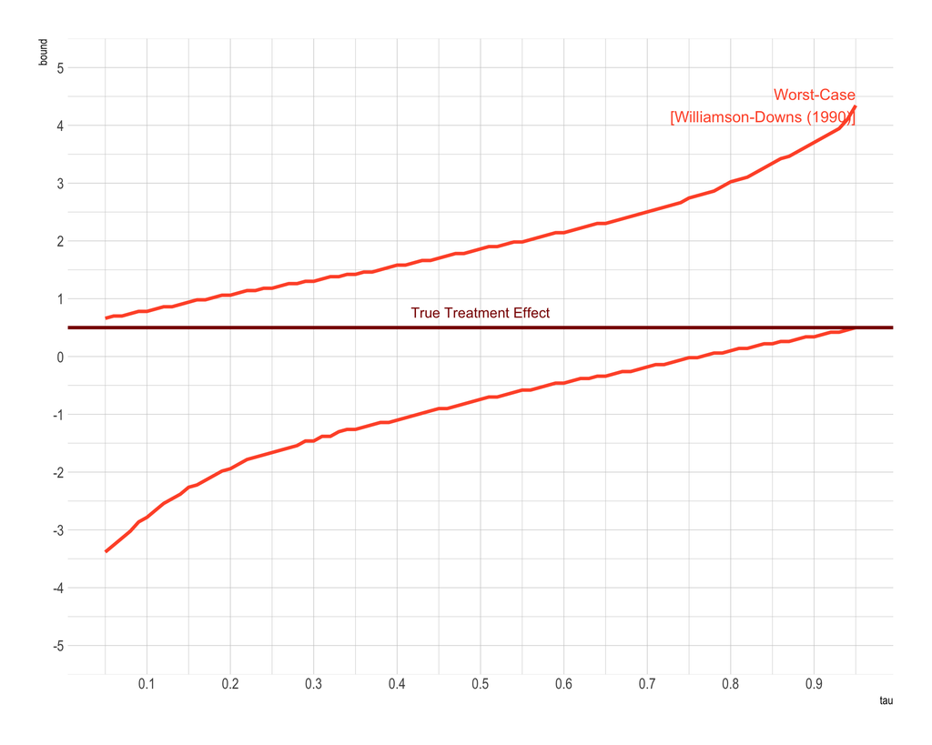

Figure 1: Worst-Case (Williamson and Downs [1990]) Bounds

```r
qwdu <- quantile(F.wd.l, tau, type=1)
qwdl <- quantile(F.wd.u, tau, type=1)

df_wd <-
  data.frame(tau = c(tau,tau), bound = c(qwdu,qwdl), type=c(rep("upper",length(qwdu)),rep("lower",length(qwdl)))) %>%
  mutate(method ="Worst-Case\n[Williamson-Downs (1990)]") %>%
  mutate(label = ifelse(type=="upper","Worst-Case\n[Williamson-Downs (1990)]",""))

col_scheme <- c("#FF5733" ) # Williamson and Downs

df_wd %>%
  mutate(type = paste0(type,method)) %>%
  ggplot(aes(x = tau, y = bound, group = type, colour = method)) +
  geom_line(lwd=1.25) +
  geom_hline(aes(yintercept = params$delta), colour = "darkred",lwd=1.25) +
  scale_color_manual(values = col_scheme) +
  geom_dl(method = list("last.points",hjust=1),aes(label = label)) +
  scale_x_continuous(breaks = seq(0,1,0.1)) +
  theme(legend.position = "none") +
  annotate("text",x = 0.5, y = params$delta, label = "True Treatment Effect",vjust=-1,colour = "darkred") +
  scale_y_continuous(limits = c(-5,5),breaks = seq(-5,5,1))
```

# Bounds Under Stochastic Increasingness

Frandsen and Lefgrens (2021)

$\begin{aligned} & \hat{F}_{\Delta \mid 0}^L(t \mid Y(0)=y):=\max \left\{0, \frac{\hat{F}_1(y+t)-\hat{F}_0(y)}{1-\hat{F}_0(y)}\right\} \\ & \hat{F}_{\Delta \mid 0}^U(t \mid Y(0)=y):=\min \left\{1, \frac{\hat{F}_1(y+t)}{\hat{F}_0(y)}\right\} .\end{aligned}$

$\begin{aligned} & \Delta^L(Y(d))=\int t d F_{\Delta \mid Y(d)}^U(t \mid Y(d)) \\ & \Delta^U(Y(d))=\int t d F_{\Delta \mid Y(d)}^L(t \mid Y(d))\end{aligned}$

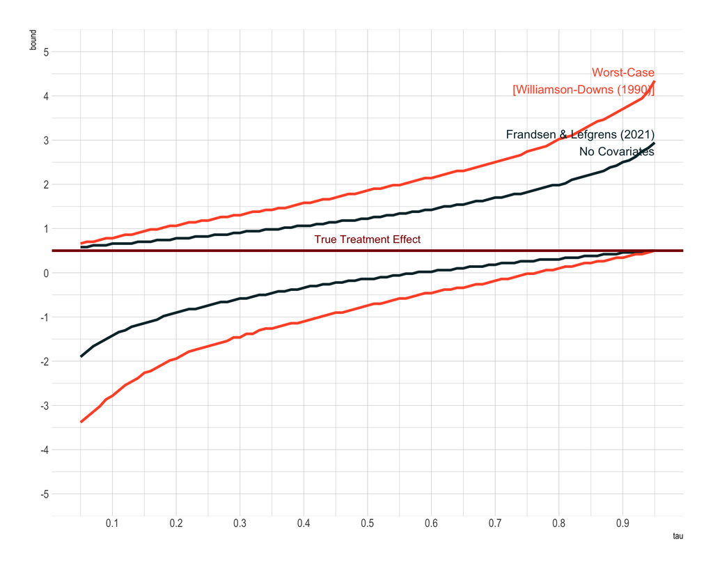

Figure 2: Treatment Effect Distribution Bounds

```r
i1 <- # Index of treated observations
  df %>%
  mutate(i = row_number()) %>%
  filter(D==1) %>%
  pull(i)

i0 <- # index of untreated observations
  df %>%
  mutate(i = row_number()) %>%
  filter(D==0) %>%
  pull(i)


F0_fl <-# ecdf for untreated defined across the support of y
  y_ %>% map_dbl(~({
    .y = .x
    mean(df$Y[i0] <= .y)
  })) %>% BMisc::makeDist(y_, .)


F1_fl <-# ecdf for treated defined across the support of y
  y_ %>% map_dbl(~({
    .y = .x
    mean(df$Y[i1] <= .y )
  })) %>% BMisc::makeDist(y_, .)

# Construct bounds
pb <- progress_bar$new(total = length(delta_))
F_l_fl_ <- # Lower bound
  delta_ %>% map(~{ # outer loop is over possible values of the treatment effect
    delt <- .x
    pb$tick()
    y0 %>% # inner loop is over observed outcome values among untreated
      map_dbl(~({
        y0_ = .x
        (F1_fl(y0_ + delt)-F0_fl(y0_))/(1-F0_fl(y0_))
      }))  %>%
      map_dbl(~(max(0,.x,na.rm=TRUE))) %>%
      mean(.)
  }) %>%
  unlist()

pb <- progress_bar$new(total = length(delta_))
F_u_fl_ <-  # Upper bound
  delta_ %>% map(~{ # outer loop is over possible values of the treatment effect
    delt <- .x
    pb$tick()
    y0 %>% # inner loop is over observed outcome values among untreated
      map_dbl(~({
        y0_ = .x
        (F1_fl(y0_+delt))/(F0_fl(y0_))
      }))  %>%
      map_dbl(~(min(1,.x,na.rm=TRUE))) %>%
      mean(.)
  }) %>%
  unlist()


# Convert into an ECDF
F.fl.l <- approxfun(delta_,  F_l_fl_, method = "constant", yleft = 0, yright = 1,
                    f = 0, ties = "ordered")
class(F.fl.l) <- c("ecdf", "stepfun", class(F.fl.l))
assign("nobs", length(delta_), envir = environment(F.fl.l))

F.fl.u <- approxfun(delta_,  F_u_fl_, method = "constant", yleft = 0, yright = 1,
                    f = 0, ties = "ordered")
class(F.fl.u) <- c("ecdf", "stepfun", class(F.fl.u))
assign("nobs", length(delta_), envir = environment(F.fl.u))

# Get the values for each quantile via the inverse CDF
qflu <- quantile(F.fl.l, tau, type=1)
qfll <- quantile(F.fl.u, tau, type=1)


df_fl <- # Collect results into a data frame
  data.frame(tau = c(tau,tau), bound = c(qflu,qfll), type=c(rep("upper",length(qflu)),rep("lower",length(qfll)))) %>%
  mutate(method = "Frandsen & Lefgrens (2021)") %>%
  mutate(label = ifelse(type=="upper","Frandsen & Lefgrens (2021)\nNo Covariates",""))


## Plot the results

col_scheme <- c("#0A2E36" ,# Frandsen & Lefgrens (No X)
                "#FF5733" ) # Williamson and Downs

df_fl %>%
  bind_rows(df_wd) %>%
    mutate(method = factor(method, levels = c("Frandsen & Lefgrens (2021)"     ,       "Frandsen & Lefgrens (2021) Covariates", "Worst-Case\n[Williamson-Downs (1990)]"))) %>%
  mutate(type = paste0(type,method)) %>%
  ggplot(aes(x = tau, y = bound, group = type, colour = method)) +
  geom_line(lwd = 1.25) +
  geom_hline(aes(yintercept = params$delta), colour = "darkred",lwd=1.25) +
  scale_color_manual(values = col_scheme) +
  geom_dl(method = list("last.points",hjust=1),aes(label = label)) +
  scale_x_continuous(breaks = seq(0,1,0.1)) +
  theme(legend.position = "none") +
  annotate("text",x = 0.5, y = params$delta, label = "True Treatment Effect",vjust=-1,colour = "darkred") +
  scale_y_continuous(limits = c(-5,5),breaks = seq(-5,5,1))
```

## Incorporating Covariates

$F_{\Delta \mid Y(0), X}^L(t \mid Y(0), X):= \begin{cases}0, & Y(0)+t<\tilde{Y}(1 \mid X), \\ \frac{F_{1 \mid X}(Y(0)+t \mid X)-F_{0 \mid X}(Y(0) \mid X)}{1-F_{0 \mid X}(Y(0) \mid X)}, & Y(0)+t \geq \tilde{Y}(1 \mid X),\end{cases}$

$F_{\Delta \mid Y(0), X}^U(t \mid Y(0), X):= \begin{cases}\frac{F_{1 \mid X}(Y(0)+t \mid X)}{F_{0 \mid X}(Y(0) \mid X)}, & Y(0)+t \leq \tilde{Y}(1 \mid X) \\ 1, & Y(0)+t \geq \tilde{Y}(1 \mid X)\end{cases}$

$\begin{aligned} & F_{\Delta \mid Y(d)}^L(t \mid Y(d))=E\left[F_{\Delta \mid Y(d), X}^L(t \mid Y(d), X) \mid Y(d)\right] \\ & F_{\Delta \mid Y(d)}^U(t \mid Y(d))=E\left[F_{\Delta \mid Y(d), X}^U(t \mid Y(d), X) \mid Y(d)\right]\end{aligned}$

$\begin{aligned} & \Delta^L(Y(d))=\int t d F_{\Delta \mid Y(d)}^U(t \mid Y(d)) \\ & \Delta^U(Y(d))=\int t d F_{\Delta \mid Y(d)}^L(t \mid Y(d))\end{aligned}$

$\begin{aligned} & \hat{F}_{\Delta \mid 0, X}^L\left(t \mid Y_j(0), X_j\right):=\max \left\{0, \frac{\hat{F}_{1 \mid X}\left(Y_j(0)+t \mid X_j\right)-\hat{F}_{0 \mid X}\left(Y_j(0) \mid X_j\right)}{1-\hat{F}_{0 \mid X}\left(Y_j(0) \mid X_j\right)}\right\} \\ & \hat{F}_{\Delta \mid 0, X}^U\left(t \mid Y_j(0), X_j\right):=\min \left\{1, \frac{\hat{F}_{1 \mid X}\left(Y_j(0)+t \mid X_j\right)}{\hat{F}_{0 \mid X}\left(Y_j(0) \mid X_j\right)}\right\} .\end{aligned}$

```r
i1 <-  # index of treated observations
  df %>%
  mutate(i = row_number()) %>%
  filter(D==1) %>%
  pull(i)

i0 <-  # index of untreated observations
  df %>%
  mutate(i = row_number()) %>%
  filter(D==0) %>%
  pull(i)

X1 <- # X values of treated observations
  df %>%
  filter(D==1) %>%
  pull(X)

X0 <- # X values of untreated observations
  df %>%
  filter(D==0) %>%
  pull(X)
```

We next create conditional CDFs, with a different CDF constructed for each untreated group $X$ value.

The short way uses parametric quantile regression (`rq()`). This specification assumes a model that is linear in parameters.

```r
taus0 <- sort(ecdf(y0)(y0))
quantreg_fit <- quantreg::rq(Y ~ X, tau = taus0, data = df %>% filter(D==0))
pvals <- predict(quantreg_fit,newdata = data.frame(X=X0), stepfun=TRUE)
hatF0X <- pvals %>% map(~(.x(taus0))) %>%
  map(~(BMisc::makeDist(.x,taus0)))


taus1 <- sort(ecdf(y1)(y1))
quantreg_fit <- quantreg::rq(Y ~ X, tau = taus0, data = df %>% filter(D==1))
pvals <- predict(quantreg_fit,newdata = data.frame(X=X0), stepfun=TRUE)
hatF1X <- pvals %>% map(~(.x(taus0))) %>%
  map(~(BMisc::makeDist(.x,taus0)))
```

A (much) longer, but nonparametric approach, is to fit a nonparametric regression. In this example code, we fit a *generalized additive model* (GAM) with a logit link (for the constructed binary outcome needed to estimate the CDF).

Note that the treatment effect bounds calcualted under a GAM vs. a parametric quantile regression approach for the condtiional CDFs are nearly identical in this example—though this will not generally be true!

```r
# This version constructs a full CDF for each X value
pb <- progress_bar$new(total = length(y0))
hatF0X <-
  map(X0, ~({
    # for each untreated observation j
    xx = .x
    pb$tick()
    hatF0X_ <-
      y_ %>% map_dbl( ~({
        yy = .x
        # nonparameterically regress an indicator Y_i <= Y_j on X_i in the untreated subsample
        IY = as.integer(df$Y[i0] <= yy)
        X <- X0
        dat <- cbind.data.frame(IY, X) %>%
          set_names(c("IY", "X"))

        fit <- gam(IY ~ s(X), data = dat, family = "binomial")
        # construct predicted value
        predict(fit, newdata = data.frame(X = xx), type = "response")

      })) %>%
      BMisc::makeDist(y_, .) # make this into an ecdf

    hatF0X_
  }))
write_rds(hatF0X,"posts/extending-the-toolkit-experimental/results/hatF0X.rds")

pb <- progress_bar$new(total = length(X0))
hatF1X <-
  map(X0, ~ ({
    # for each untreated observation j
    xx = .x
    pb$tick()
    hatF1X_ <-
      y_ %>% map_dbl( ~ ({
        yy = .x
        # nonparameterically regress an indicator Y_i <= Y_j on X_i in the treated subsample
        IY = as.integer(df$Y[i1] <= yy)
        X <- X1
        dat <- cbind.data.frame(IY, X) %>%
          set_names(c("IY", "X"))

        fit <- gam(IY ~ s(X), data = dat, family = "binomial")
        # construct predicted value
        predict(fit, newdata = data.frame(X = xx), type = "response")

      })) %>%
      BMisc::makeDist(y_, .) # make this into an ecdf
    hatF1X_
  }))
write_rds(hatF1X,"posts/extending-the-toolkit-experimental/results/hatF1X.rds")
```

We next plug these condtiional CDFs into the formulas to obtain the CDF of the treatment effect bounds.

```r
pb <- progress_bar$new(total = length(delta_))
F_l_flX_ <-
  delta_ %>% map(~{ # outer loop is over possible values of the treatment effect
    delt <- .x
    pb$tick()
      map2_dbl(y0,X0,~({
        y0_ = .x
        xx_ = .y
        i = which(X0==xx_); i
        F1_fl_tmp <- hatF1X[[i]]
        F0_fl_tmp <- hatF0X[[i]]
        (F1_fl_tmp(y0_ + delt)-F0_fl_tmp(y0_))/(1-F0_fl_tmp(y0_))
      }))  %>%
      map_dbl(~(max(0,.x,na.rm=TRUE))) %>%
      mean(.)
  }) %>%
  unlist()
# Make it into a proper eCDF object.
F.flX.l <- approxfun(delta_,  F_l_flX_, method = "constant", yleft = 0, yright = 1,
                    f = 0, ties = "ordered")
class(F.flX.l) <- c("ecdf", "stepfun", class(F.flX.l))
assign("nobs", length(delta_), envir = environment(F.flX.l))

pb <- progress_bar$new(total = length(delta_))
F_u_flX_ <-
  delta_ %>%
  map(~{ # outer loop is over possible values of the treatment effect
    delt <- .x
    pb$tick()

      map2_dbl(y0,X0,~({
        y0_ = .x
        xx_ = .y
        i = which(X0==xx_); i
        F1_fl_tmp <- hatF1X[[i]]
        F0_fl_tmp <- hatF0X[[i]]

        (F1_fl_tmp(y0_+delt))/(F0_fl_tmp(y0_))
      }))  %>%
      map_dbl(~(min(1,.x,na.rm=TRUE))) %>%
      mean(.)
  }) %>%
  unlist()
# Make it into a proper eCDF object.
F.flX.u <- approxfun(delta_,  F_u_flX_, method = "constant", yleft = 0, yright = 1,
                    f = 0, ties = "ordered")
class(F.flX.u) <- c("ecdf", "stepfun", class(F.flX.u))
assign("nobs", length(delta_), envir = environment(F.flX.u))
```

First, let’s take a look at bounds on various quantiles of the treatment effect (QoTT):

```r
qflXu <- quantile(F.flX.l, tau, type=1)
qflXl <- quantile(F.flX.u, tau, type=1)

df_flX <-
  data.frame(tau = c(tau,tau), bound = c(qflXu,qflXl), type=c(rep("upper",length(qflXu)),rep("lower",length(qflXl)))) %>%
  mutate(method = "Frandsen & Lefgrens (2021) Covariates") %>%
  mutate(label = ifelse(type=="upper","Frandsen & Lefgrens (2021)\nWith Covariates",""))
```

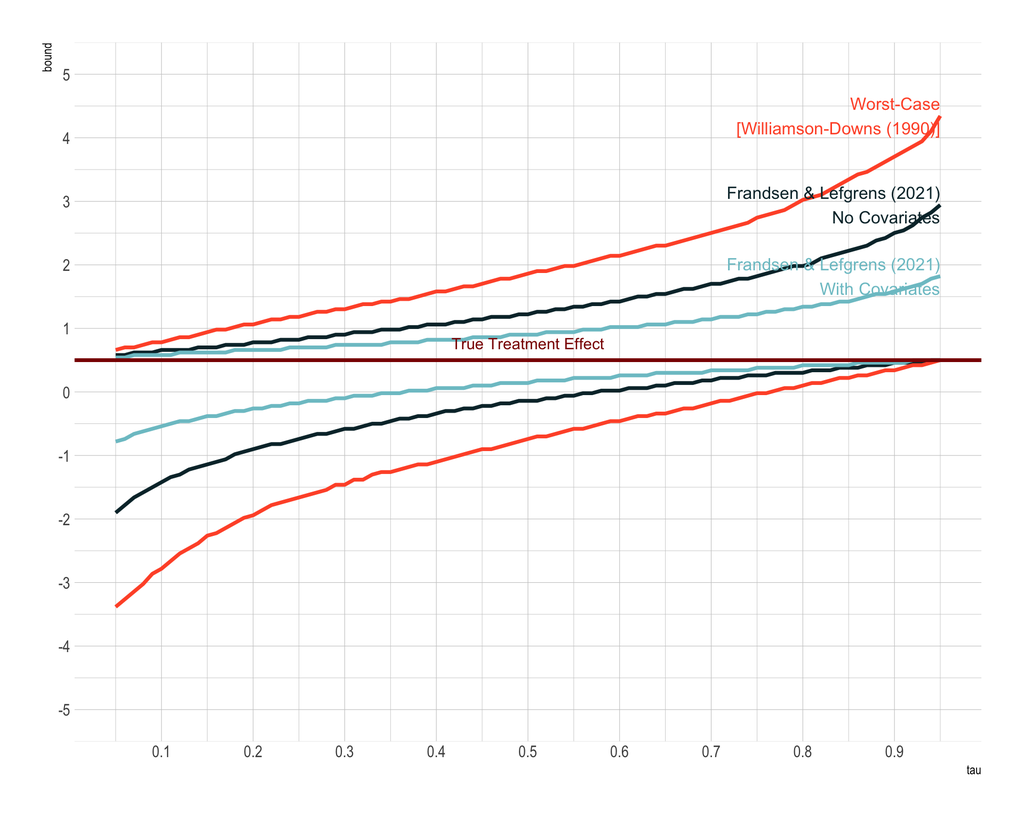

Figure 3: Treatment Effect Distribution Bounds with Covariates

```r
col_scheme <- c("#0A2E36" ,# Frandsen & Lefgrens (No X)
                "#7DC4CC", # Frandsen & Lefgrens (X)
                "#FF5733" ) # Williamson and Downs

df_fl %>%
  bind_rows(df_flX) %>%
  bind_rows(df_wd) %>%
  mutate(method = factor(method, levels = c("Frandsen & Lefgrens (2021)"     ,       "Frandsen & Lefgrens (2021) Covariates", "Worst-Case\n[Williamson-Downs (1990)]"))) %>%
  mutate(type = paste0(type,method)) %>%
  ggplot(aes(x = tau, y = bound, group = type, colour = method)) +
  geom_line(lwd=1.25) +
  geom_hline(aes(yintercept = params$delta), colour = "darkred",lwd=1.25) +
  scale_color_manual(values=col_scheme) +
  geom_dl(method = list("last.points",hjust=1),aes(label = label)) +
  scale_x_continuous(breaks = seq(0,1,0.1)) +
  theme(legend.position = "none") +
  annotate("text",x = 0.5, y = params$delta, label = "True Treatment Effect",vjust=-1,colour = "darkred") +
  scale_y_continuous(limits = c(-5,5),breaks = seq(-5,5,1))
```